# PEC4: Predicción de dolencias cardiacas a partir de un electrocardiograma

Demetrio Muñoz Alvarez

2024-01-28

# Introducción

```r
dataset <- read.csv("ECGCvdata.csv") # Cargamos nuestro conjunto de datos.
```

En esta última actividad evaluable, se realizará un análisis predictivo del tipo de dolencia cardíaca utilizando los datos de los pacientes recopilados en el conjunto de datos ECGCvdata.csv. Para analizar estas dolencias, se implementarán distintos algoritmos: **k-Nearest Neighbour, Naive Bayes, Artificial Neural Network, Support Vector Machine, Árbol de Decisión y Random Forest**.

Este informe se dividirá en tres partes. La primera parte mostrará un análisis descriptivo del conjunto de datos. Además, se tratarán los datos en busca de valores faltantes y se procederá a su eliminación. La segunda parte consistirá en dividir el conjunto de datos en datos de entrenamiento y prueba para luego entrenar los distintos algoritmos. Por último, se compararán los modelos y se concluirá cuál o cuáles son los mejores para predecir las dolencias cardíacas.

# Exploración y tratamiento de los datos

El conjunto de datos ECGCvdata.csv esta formado por 1200 observaciones y 56 variables.

En un primer contacto, mostramos las primeras y las últimas seis entradas. En este caso, se elimina la columna **“RECORD”** del conjunto de datos, ya que no aporta información útil para nuestros posteriores análisis. Por último, mostramos el resumen de las diez primeras entradas.

```r
head(dataset) # Mostramos las primeras entradas del conjunto de datos.
```

```
  RECORD hbpermin       Pseg      PQseg     QRSseg      QRseg     QTseg      RSseg
1      1 74.92567 0.07650794 0.10888889 0.08825397 0.04357143 0.1930159 0.04468254
2      2 68.50347 0.07248264 0.09618056 0.09392361 0.04626736 0.1934896 0.04765625
3      3 83.48860 0.07115385 0.08660969 0.03952991 0.01858974 0.1324786 0.02094017
4      4 68.50347 0.08281250 0.10815972 0.09036458 0.04522569 0.1888021 0.04513889
5      5 82.08000 0.07076023 0.10263158 0.10102339 0.04941520 0.1937135 0.05160819
6      6 66.96000 0.07025090 0.06191756 0.09094982 0.04596774 0.1912186 0.04498208
       STseg       Tseg     PTseg    ECGseg   QRtoQSdur   RStoQSdur   RRmean   PPmean
1 0.10476190 0.13047619 0.3019048 0.4261111 0.001371360 0.001406417 291.7941 291.7353
2 0.09956597 0.08914931 0.2896701 0.3666667 0.001368380 0.001409398 318.3871 318.3226
3 0.09294872 0.09444444 0.2190883 0.2932336         NaN         NaN 259.7632 259.5263
4 0.09843750 0.08828125 0.2969618 0.3731771 0.001390204 0.001387574 312.8387 312.8387
5 0.09269006 0.08596491 0.2963450 0.3750731 0.001358812 0.001418966 260.7838 260.8649
6 0.10026882 0.09713262 0.2531362 0.3302867 0.001403823 0.001373955 313.9333 313.9333
     PQdis  PonQdis    PRdis  PonRdis    PSdis  PonSdis     PTdis   PonTdis  PToffdis
```

[output cut: 34 more lines]

```r
tail(dataset) # Mostramos las últimas entradas del conjunto de datos.
```

```
     RECORD hbpermin       Pseg      PQseg     QRSseg      QRseg     QTseg       RSseg
1195   1195 72.19200 0.05125762 0.07212271 0.03229802 0.01648247 0.1164253 0.015815549
1196   1196 91.39200 0.05135290 0.06250000 0.01915015 0.01005145 0.1180450 0.009098704
1197   1197 61.44000 0.05735518 0.06154726 0.06126143 0.03134527 0.1340987 0.029916159
1198   1198 93.32271 0.05892721 0.10913681 0.08093559 0.04030107 0.1681117 0.040634527
1199   1199 63.74400 0.06149962 0.10127668 0.08179306 0.04115854 0.1459127 0.040634527
1200   1200 70.65600 0.06307165 0.10542111 0.08303163 0.04153963 0.1714939 0.041491997
          STseg       Tseg     PTseg    ECGseg   QRtoQSdur   RStoQSdur    RRmean
1195 0.08412729 0.07993521 0.1885480 0.2367092         NaN         NaN 105.46237
1196 0.09889482 0.08655678 0.1805450 0.2213700         NaN         NaN  84.11017
1197 0.07283727 0.09098704 0.1956460 0.2788681 0.003986151 0.003826349 124.55696
1198 0.08717607 0.08808117 0.2772485 0.3437024 0.003871321 0.003941179  81.98347
1199 0.06411966 0.08117378 0.2471894 0.3308403 0.003940478 0.003872022 120.07317
1200 0.08846227 0.08165015 0.2769150 0.3415587 0.003894670 0.003917830 107.96703
        PPmean     PQdis   PonQdis     PRdis   PonRdis     PSdis   PonSdis    PTdis
```

[output cut: 34 more lines]

```r
dataset <- dataset[,-1] # Eliminamos la columna "RECORD" ya que no aporta informacion útil a nuestros datos.
summary(dataset[,1:10]) # Mostramos el un resumen de las 10 primeras entradas.
```

```
    hbpermin           Pseg             PQseg             QRSseg
 Min.   : 12.86   Min.   :0.02156   Min.   :0.04453   Min.   :0.00000
 1st Qu.: 67.56   1st Qu.:0.05394   1st Qu.:0.06034   1st Qu.:0.01510
 Median : 79.87   Median :0.06064   Median :0.07518   Median :0.04469
 Mean   : 81.89   Mean   :0.06090   Mean   :0.07810   Mean   :0.04824
 3rd Qu.: 96.00   3rd Qu.:0.06685   3rd Qu.:0.09519   3rd Qu.:0.08303
 Max.   :160.50   Max.   :0.09532   Max.   :0.14558   Max.   :0.12016
     QRseg              QTseg             RSseg              STseg
 Min.   :0.000000   Min.   :0.09876   Min.   :0.000000   Min.   :0.05234
 1st Qu.:0.007804   1st Qu.:0.11602   1st Qu.:0.007143   1st Qu.:0.08942
 Median :0.022676   Median :0.13702   Median :0.021965   Median :0.09782
 Mean   :0.024437   Mean   :0.14154   Mean   :0.023800   Mean   :0.09330
 3rd Qu.:0.041915   3rd Qu.:0.16631   3rd Qu.:0.041097   3rd Qu.:0.10120
 Max.   :0.065278   Max.   :0.21111   Max.   :0.058333   Max.   :0.13844
      Tseg             PTseg
 Min.   :0.03494   Min.   :0.1500
 1st Qu.:0.09005   1st Qu.:0.1773
 Median :0.09921   Median :0.2152
 Mean   :0.10271   Mean   :0.2196
 3rd Qu.:0.11241   3rd Qu.:0.2603
 Max.   :0.19841   Max.   :0.3473
```

La siguiente tabla muestra el número de casos para cada tipo de dolencia:

| ECG_signal | Frecuencia |
| --- | --- |
| AFF | 300 |
| ARR | 300 |
| CHF | 300 |
| NSR | 300 |

Si analizamos la estructura de los datos, podemos observar que casi todas las variables son de tipo numérico, excepto la variable que muestra las clases, que es de tipo categórica. En algunas de estas variables, observamos valores faltantes que trataremos en el siguiente paso.

```r
str(dataset) # Estructura de las variables.
```

```
'data.frame':   1200 obs. of  55 variables:
 $ hbpermin  : num  74.9 68.5 83.5 68.5 82.1 ...
 $ Pseg      : num  0.0765 0.0725 0.0712 0.0828 0.0708 ...
 $ PQseg     : num  0.1089 0.0962 0.0866 0.1082 0.1026 ...
 $ QRSseg    : num  0.0883 0.0939 0.0395 0.0904 0.101 ...
 $ QRseg     : num  0.0436 0.0463 0.0186 0.0452 0.0494 ...
 $ QTseg     : num  0.193 0.193 0.132 0.189 0.194 ...
 $ RSseg     : num  0.0447 0.0477 0.0209 0.0451 0.0516 ...
 $ STseg     : num  0.1048 0.0996 0.0929 0.0984 0.0927 ...
 $ Tseg      : num  0.1305 0.0891 0.0944 0.0883 0.086 ...
 $ PTseg     : num  0.302 0.29 0.219 0.297 0.296 ...
 $ ECGseg    : num  0.426 0.367 0.293 0.373 0.375 ...
 $ QRtoQSdur : num  0.00137 0.00137 NaN 0.00139 0.00136 ...
 $ RStoQSdur : num  0.00141 0.00141 NaN 0.00139 0.00142 ...
 $ RRmean    : num  292 318 260 313 261 ...
```

[output cut: 41 more lines]

Los valores faltantes se muestran en la siguiente tabla:

```r
valores_nan <- table(is.na(dataset)) # Contamos y mostramos los valores "NaN"
valores_nan
```

```
FALSE  TRUE
59636  6364
```

```r
dataset_nan <- dataset[, colSums(is.na(dataset)) == 0]
```

Como indica el enunciado de la actividad, vamos a tratar los valores faltantes eliminando aquellas variables que presenten algún valor ‘NaN’. Una vez eliminados los datos faltantes nuestro conjunto de datos muestra 1200 observaciones y 46 variables.

En la siguiente gráfica, observamos la distribución de las variables. Las variables no se distribuyen de forma uniforme y se observan valores atípicos.

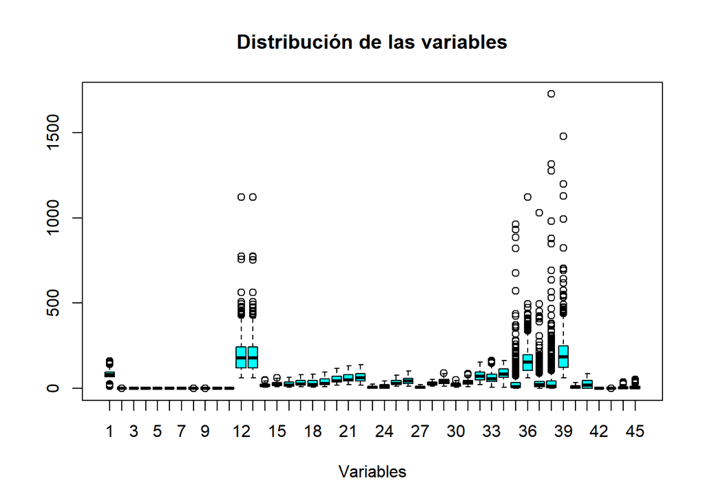

## Normalización

Con este conjunto de datos, vamos a realizar los algoritmos, pero antes, como hemos observado anteriormente, algunas variables muestran números enteros y otras números decimales. Además, la escala de las variables es diferente. Por ello, se va a proceder a hacer una normalización de los datos. Para realizar esta normalización, se va a crear una función que se aplicará al conjunto de datos siguiendo la formula:
$$Normalización = (x - min(x)) /
(max(x) - min(x))$$

```r
ECG_signal <- dataset_nan[,46] # Extraemos la columna de clases antes de normalizar los datos.
dataset_norm <- as.data.frame(lapply(dataset_nan[1:45], normalizar)) # Aplicamos la funcion 'lapply()' para aplicar la normalización a nuestras variables.
data_norm <- data.frame(ECG_signal, dataset_norm) # Creamos el conjunto de datos normalizado.
```

Con los datos normalizados, realizamos una exploración visual de nuestros datos. Examinamos la correlación entre las variables y presentamos otro gráfico de cajas con los datos normalizados.

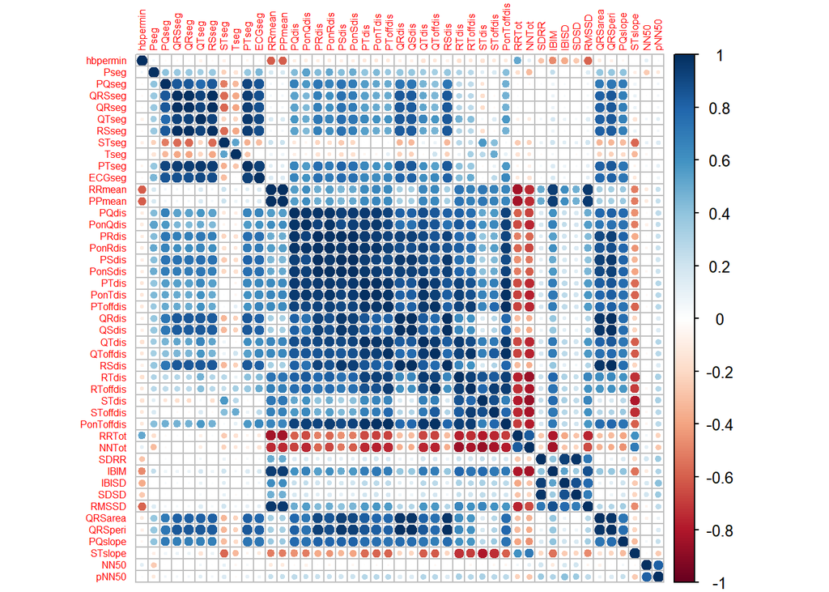

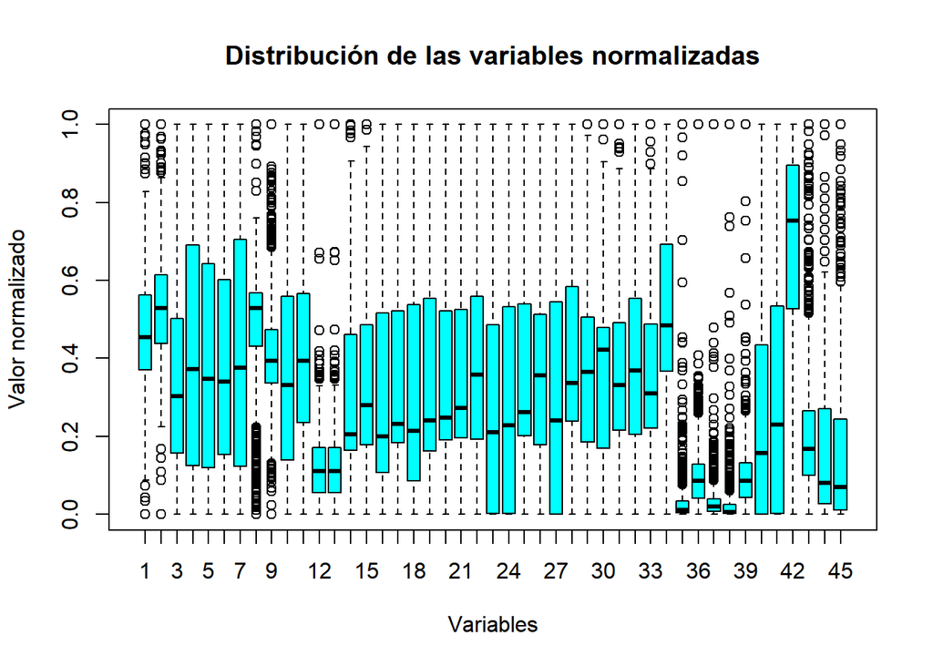

# Partición de los datos en entrenamiento/prueba

El conjunto de datos resultante de la exploración y manejo de los datos se dividirá en dos partes: una para el conjunto de entrenamiento y otra para el conjunto de prueba. Para el conjunto de entrenamiento, dividiremos los datos en un 67% de las observaciones totales, mientras que el conjunto de prueba contendrá el 33% de las observaciones restantes.

```r
set.seed(seed)

# Extraemos los indices de una muestra aleatoria de la filas de los datos
indices <- sample(1:nrow(data_norm), size = nrow(data_norm), replace = FALSE)
# Tamaño del conjunto de entrenamiento
train_size <- round(train_part * nrow(data_norm))

# Dividimos los datos en entrenamiento/prueba.
train_data <- data_norm[indices[1:train_size], ]
test_data <- data_norm[indices[(train_size + 1):nrow(data_norm)], ] # Conjunto de prueba (33%).

# Extraemos las labels/etiquetas.
train_label <- train_data$ECG_signal
test_label <- test_data$ECG_signal
```

# Aplicación de Algortimos

En esta sección, exploraremos distintos algoritmos para la clasificación de nuestros datos. Utilizaremos la misma división de los datos para cada algoritmo y seguiremos las directrices del libro de referencia (Lantz 2019) para implementar los modelos. Los algoritmos a explorar son:

1. k-Nearest Neighbour
2. Naive Bayes
3. Artificial Neural Network
4. Support Vector Machine
5. Árbol de Clasificación
6. Random Forest

La implementación de estos algoritmos la realizaremos íntegramente con R y RStudio.

## k-Nearest Neighbour (kNN)

Para implementar el algoritmo **k-Nearest Neighbors (kNN)**, utilizamos el paquete *`class`* (Venables and Ripley 2002) con la función `knn()` y exploraremos los valores de k = 1, 3, 5, 7, 11. Posteriormente, se presentarán las matrices de confusión para cada modelo utilizando el paquete *‘caret’* (Kuhn and Max 2008).

```r
set.seed(seed)

# Listas para almacenar los modelos y las matrices resultantes.
models <- list()
confusion_matrices <- list()

for (k in k_values) {
  model_name <- paste("model_knn_k", k, sep = "")
  # Entrenamiento del modelo con los datos establecidos para cada valor de 'k':
  model <- knn(train = train_data[,-1], test = test_data[,-1], cl = train_data$ECG_signal, k = k)
  # Almacenamos cada modelo resultante de cada valor de 'k':
  models[[model_name]] <- model

  # Calculamos la matriz de confusión y almacenamos:
  cm <- confusionMatrix(data = model, reference = as.factor(test_data$ECG_signal))
  confusion_matrices[[model_name]] <- cm
}
# Imprimimos las matrices de confusión:
print(confusion_matrices)
```

```
$model_knn_k1
Confusion Matrix and Statistics

          Reference
Prediction AFF ARR CHF NSR
       AFF 102   0   2   0
       ARR   0  80   0   0
       CHF   9   0 104   0
       NSR   0   0   0  99

Overall Statistics

               Accuracy : 0.9722
                 95% CI : (0.9508, 0.9861)
    No Information Rate : 0.2803
    P-Value [Acc > NIR] : < 2.2e-16

                  Kappa : 0.9628

 Mcnemar's Test P-Value : NA

Statistics by Class:

                     Class: AFF Class: ARR Class: CHF Class: NSR
Sensitivity              0.9189      1.000     0.9811       1.00
Specificity              0.9930      1.000     0.9690       1.00
Pos Pred Value           0.9808      1.000     0.9204       1.00
Neg Pred Value           0.9692      1.000     0.9929       1.00
Prevalence               0.2803      0.202     0.2677       0.25
Detection Rate           0.2576      0.202     0.2626       0.25
Detection Prevalence     0.2626      0.202     0.2854       0.25
Balanced Accuracy        0.9560      1.000     0.9750       1.00

$model_knn_k3
Confusion Matrix and Statistics

          Reference
Prediction AFF ARR CHF NSR
       AFF  96   0   3   0
       ARR   0  80   0   0
```

[output cut: 109 more lines]

```
                  Kappa : 0.9019

 Mcnemar's Test P-Value : NA

Statistics by Class:

                     Class: AFF Class: ARR Class: CHF Class: NSR
Sensitivity              0.8288      1.000     0.9057       1.00
Specificity              0.9649      1.000     0.9345       1.00
Pos Pred Value           0.9020      1.000     0.8348       1.00
Neg Pred Value           0.9354      1.000     0.9644       1.00
Prevalence               0.2803      0.202     0.2677       0.25
Detection Rate           0.2323      0.202     0.2424       0.25
Detection Prevalence     0.2576      0.202     0.2904       0.25
Balanced Accuracy        0.8969      1.000     0.9201       1.00
```

Comparación de Modelos (‘kNN’)

|  | Modelo | Accuracy | Kappa | Error_rate | Sensitivity_AFF | Sensitivity_ARR | Sensitivity_CHF | Sensitivity_NSR |
| --- | --- | --- | --- | --- | --- | --- | --- | --- |
| 1 | kNN k = 1 | 0.972 | 0.963 | 0.028 | 0.919 | 1 | 0.981 | 1 |
| 2 | kNN k = 3 | 0.955 | 0.939 | 0.045 | 0.865 | 1 | 0.972 | 1 |
| 4 | kNN k = 7 | 0.942 | 0.922 | 0.058 | 0.829 | 1 | 0.962 | 1 |
| 3 | kNN k = 5 | 0.939 | 0.919 | 0.061 | 0.820 | 1 | 0.962 | 1 |
| 5 | kNN k = 11 | 0.927 | 0.902 | 0.073 | 0.829 | 1 | 0.906 | 1 |

De todos los valores de **k** (1, 3, 5, 7, 11), el modelo con el valor de kNN k = 1 tiene la mejor precisión y valor de kappa, con un 97.2% y 96.3%, respectivamente. Además, presenta el menor porcentaje de error con un 2.8%.

También observamos en la tabla los valores de sensibilidad de cada clase. El modelo con las mejores métricas tiene un valor de sensibilidad del 91.9% para la clase AFF, 100% para la clase ARR, 98.1% para la clase CHF y 100% para la última clase NSR.

## Naive Bayes

En este apartado, implementamos el algoritmo de **Naive Bayes** con el paquete *`e1071`* (Meyer et al. 2023) y visualizaremos las matrices de confusión con el paquete *‘caret’*. Exploraremos la opción de activar (laplace = 1) o no activar (laplace = 0) **Laplace**.

```r
set.seed(seed)

# Modelo Nain Bayes con el valor laplace = 0.
naive_model_1 <- naiveBayes(train_data, train_data$ECG_signal, laplace=0)
naive_test_pred_1 <- predict(naive_model_1, test_data)
confusion_matrix_naive_1 <- confusionMatrix(naive_test_pred_1, as.factor(test_label))
print(confusion_matrix_naive_1)
```

```
Confusion Matrix and Statistics

          Reference
Prediction AFF ARR CHF NSR
       AFF  99   8  15   2
       ARR   1  72   0   0
       CHF  11   0  91   0
       NSR   0   0   0  97

Overall Statistics

               Accuracy : 0.9066
                 95% CI : (0.8735, 0.9334)
    No Information Rate : 0.2803
    P-Value [Acc > NIR] : < 2.2e-16

                  Kappa : 0.8746

 Mcnemar's Test P-Value : NA

Statistics by Class:

                     Class: AFF Class: ARR Class: CHF Class: NSR
Sensitivity              0.8919     0.9000     0.8585     0.9798
Specificity              0.9123     0.9968     0.9621     1.0000
Pos Pred Value           0.7984     0.9863     0.8922     1.0000
Neg Pred Value           0.9559     0.9752     0.9490     0.9933
Prevalence               0.2803     0.2020     0.2677     0.2500
Detection Rate           0.2500     0.1818     0.2298     0.2449
Detection Prevalence     0.3131     0.1843     0.2576     0.2449
Balanced Accuracy        0.9021     0.9484     0.9103     0.9899
```

```r
# Modelo Nain Bayes con el valor laplace = 1.
naive_model_2 <- naiveBayes(train_data, train_data$ECG_signa, laplace=1)
naive_test_pred_2 <- predict(naive_model_2, test_data)
confusion_matrix_naive_2 <- confusionMatrix(naive_test_pred_2, as.factor(test_label))
print(confusion_matrix_naive_2)
```

```
Confusion Matrix and Statistics

          Reference
Prediction AFF ARR CHF NSR
       AFF  99   8  16   2
       ARR   1  72   0   0
       CHF  11   0  90   0
       NSR   0   0   0  97

Overall Statistics

               Accuracy : 0.904
                 95% CI : (0.8707, 0.9312)
    No Information Rate : 0.2803
    P-Value [Acc > NIR] : < 2.2e-16

                  Kappa : 0.8712

 Mcnemar's Test P-Value : NA

Statistics by Class:

                     Class: AFF Class: ARR Class: CHF Class: NSR
Sensitivity              0.8919     0.9000     0.8491     0.9798
Specificity              0.9088     0.9968     0.9621     1.0000
Pos Pred Value           0.7920     0.9863     0.8911     1.0000
Neg Pred Value           0.9557     0.9752     0.9458     0.9933
Prevalence               0.2803     0.2020     0.2677     0.2500
Detection Rate           0.2500     0.1818     0.2273     0.2449
Detection Prevalence     0.3157     0.1843     0.2551     0.2449
Balanced Accuracy        0.9003     0.9484     0.9056     0.9899
```

Comparación de Modelos (‘Nain Bayes’)

| Modelo | Accuracy | Kappa | Error_rate | Sensitivity_AFF | Sensitivity_ARR | Sensitivity_CHF | Sensitivity_NSR |
| --- | --- | --- | --- | --- | --- | --- | --- |
| NB Laplace = 0 | 0.907 | 0.875 | 0.093 | 0.892 | 0.9 | 0.858 | 0.98 |
| NB Laplace =1 | 0.904 | 0.871 | 0.096 | 0.892 | 0.9 | 0.849 | 0.98 |

Al comparar los modelos en la tabla anterior observamos que el modelo obtenido sin activar laplace tiene una mayor precisión , el valor kappa también es superior en el modelo sin laplace y el valor de error es superior en el modelo con laplace .

Los valores de sensibilidad para el modelo con mejor precisión son 89.2% para la clase AFF, 90% para la clase ARR, 85.8% para la clase CHF y 98% para la última clase NSR.

Si ambos modelos son muy similares seleccionaremos el modelo más sencillo.

## Artificial Neural Network

Antes de implementar el modelo, realizaremos un ajuste en nuestros datos de entrenamiento y prueba. Convertiremos nuestras etiquetas a valores numéricos para poder ejecutar el modelo. En la siguiente tabla, observamos la equivalencia de la transformación de las clases de estudio:

| Clases | Clases_ann |
| --- | --- |
| AFF | 0 |
| ARR | 1 |
| CHF | 2 |
| NSR | 3 |

```r
# Ajustamos los datos de entramiento y prueba para adaptarlos al algoritmo ann.
train_data_ann <- as.matrix(train_data[,-1])
test_data_ann <- as.matrix(test_data[,-1])

# Transformamos nuestras clases a valores numericos, del 0 al 3.
train_label_ann <- as.numeric(factor(train_label)) - 1
test_label_ann <- as.numeric(factor(test_label)) - 1
```

```r
set.seed(seed)

# Modelo ann con una capa oculta.
modelo_ann_1 <- keras_model_sequential() %>%
  # Agregamos una capa densa al modelo con 15 nodos. Establecemos la activacion 'relu' para introducir no linealidades en el modelo.
  layer_dense(units = 15, activation = 'relu', input_shape = ncol(train_data_ann)) %>%
  # Capa de Dropout desactivando aleatoriamente el 20% de las neuronas para prevenir el sobreajuste.
  layer_dropout(rate = 0.2) %>%
  #Capa de salida, usamos la función de activación 'softmax'.
  layer_dense(units = 4, activation = 'softmax')
summary(modelo_ann_1)
```

```
Model: "sequential"
__________________________________________________________________________________________
 Layer (type)                           Output Shape                        Param #
==========================================================================================
 dense_1 (Dense)                        (None, 15)                          690
 dropout (Dropout)                      (None, 15)                          0
 dense (Dense)                          (None, 4)                           64
==========================================================================================
Total params: 754 (2.95 KB)
Trainable params: 754 (2.95 KB)
Non-trainable params: 0 (0.00 Byte)
__________________________________________________________________________________________
```

```r
set.seed(seed)

# Compilamos el modelo_ann_1:
modelo_ann_1 %>% compile(
  loss = 'sparse_categorical_crossentropy',
  optimizer = optimizer_adam(),
  metrics = c('accuracy')
)
# Entrenamos el model0_ann_1 y almacenamos la información en la variable "history__ann_1":
history_ann_1 <- modelo_ann_1 %>% fit(
  x = train_data_ann,
  y = train_label_ann,
  epochs = 50, # Establecemos las épocas de interacciones del entrenamiento a 50.
  validation_split = 0.2, # 20% de los datos se usarán como datos de validación.
  verbose = 2 # Nivel de detalle durante el entrenamiento.
)
```

```
21/21 - 1s - loss: 1.4220 - accuracy: 0.3048 - val_loss: 1.3673 - val_accuracy: 0.4224 - 559ms/epoch - 27ms/step
21/21 - 0s - loss: 1.2699 - accuracy: 0.4075 - val_loss: 1.2894 - val_accuracy: 0.3665 - 65ms/epoch - 3ms/step
21/21 - 0s - loss: 1.2079 - accuracy: 0.4448 - val_loss: 1.2275 - val_accuracy: 0.4099 - 48ms/epoch - 2ms/step
21/21 - 0s - loss: 1.1642 - accuracy: 0.5023 - val_loss: 1.1671 - val_accuracy: 0.5342 - 47ms/epoch - 2ms/step
21/21 - 0s - loss: 1.0992 - accuracy: 0.5708 - val_loss: 1.1097 - val_accuracy: 0.6025 - 47ms/epoch - 2ms/step
21/21 - 0s - loss: 1.0276 - accuracy: 0.6454 - val_loss: 1.0518 - val_accuracy: 0.6708 - 55ms/epoch - 3ms/step
21/21 - 0s - loss: 0.9735 - accuracy: 0.6672 - val_loss: 0.9871 - val_accuracy: 0.7019 - 54ms/epoch - 3ms/step
21/21 - 0s - loss: 0.9309 - accuracy: 0.6890 - val_loss: 0.9323 - val_accuracy: 0.7143 - 56ms/epoch - 3ms/step
21/21 - 0s - loss: 0.8851 - accuracy: 0.7092 - val_loss: 0.8826 - val_accuracy: 0.7143 - 52ms/epoch - 2ms/step
21/21 - 0s - loss: 0.8177 - accuracy: 0.7263 - val_loss: 0.8307 - val_accuracy: 0.7205 - 54ms/epoch - 3ms/step
21/21 - 0s - loss: 0.7925 - accuracy: 0.7496 - val_loss: 0.7880 - val_accuracy: 0.7329 - 51ms/epoch - 2ms/step
21/21 - 0s - loss: 0.7376 - accuracy: 0.7543 - val_loss: 0.7488 - val_accuracy: 0.7329 - 50ms/epoch - 2ms/step
21/21 - 0s - loss: 0.7276 - accuracy: 0.7714 - val_loss: 0.7121 - val_accuracy: 0.7329 - 50ms/epoch - 2ms/step
21/21 - 0s - loss: 0.6867 - accuracy: 0.7481 - val_loss: 0.6803 - val_accuracy: 0.7453 - 50ms/epoch - 2ms/step
21/21 - 0s - loss: 0.6585 - accuracy: 0.7854 - val_loss: 0.6457 - val_accuracy: 0.8012 - 50ms/epoch - 2ms/step
21/21 - 0s - loss: 0.6442 - accuracy: 0.7652 - val_loss: 0.6265 - val_accuracy: 0.7888 - 52ms/epoch - 2ms/step
21/21 - 0s - loss: 0.6308 - accuracy: 0.7636 - val_loss: 0.6017 - val_accuracy: 0.7578 - 56ms/epoch - 3ms/step
21/21 - 0s - loss: 0.5918 - accuracy: 0.8025 - val_loss: 0.5766 - val_accuracy: 0.8323 - 50ms/epoch - 2ms/step
21/21 - 0s - loss: 0.5788 - accuracy: 0.8118 - val_loss: 0.5504 - val_accuracy: 0.8758 - 51ms/epoch - 2ms/step
21/21 - 0s - loss: 0.5636 - accuracy: 0.8040 - val_loss: 0.5390 - val_accuracy: 0.8261 - 49ms/epoch - 2ms/step
21/21 - 0s - loss: 0.5506 - accuracy: 0.7760 - val_loss: 0.5207 - val_accuracy: 0.8571 - 48ms/epoch - 2ms/step
21/21 - 0s - loss: 0.5363 - accuracy: 0.7916 - val_loss: 0.5064 - val_accuracy: 0.8509 - 51ms/epoch - 2ms/step
21/21 - 0s - loss: 0.5110 - accuracy: 0.8134 - val_loss: 0.4931 - val_accuracy: 0.8634 - 51ms/epoch - 2ms/step
21/21 - 0s - loss: 0.5210 - accuracy: 0.8025 - val_loss: 0.4822 - val_accuracy: 0.8571 - 53ms/epoch - 3ms/step
21/21 - 0s - loss: 0.4906 - accuracy: 0.8196 - val_loss: 0.4689 - val_accuracy: 0.8634 - 53ms/epoch - 3ms/step
21/21 - 0s - loss: 0.4759 - accuracy: 0.8305 - val_loss: 0.4583 - val_accuracy: 0.8758 - 49ms/epoch - 2ms/step
21/21 - 0s - loss: 0.4811 - accuracy: 0.8212 - val_loss: 0.4497 - val_accuracy: 0.8571 - 53ms/epoch - 3ms/step
21/21 - 0s - loss: 0.4480 - accuracy: 0.8491 - val_loss: 0.4384 - val_accuracy: 0.8696 - 50ms/epoch - 2ms/step
21/21 - 0s - loss: 0.4533 - accuracy: 0.8289 - val_loss: 0.4291 - val_accuracy: 0.8696 - 51ms/epoch - 2ms/step
21/21 - 0s - loss: 0.4479 - accuracy: 0.8336 - val_loss: 0.4173 - val_accuracy: 0.8820 - 52ms/epoch - 2ms/step
21/21 - 0s - loss: 0.4481 - accuracy: 0.7978 - val_loss: 0.4092 - val_accuracy: 0.8820 - 53ms/epoch - 3ms/step
21/21 - 0s - loss: 0.4296 - accuracy: 0.8491 - val_loss: 0.3986 - val_accuracy: 0.9130 - 52ms/epoch - 2ms/step
21/21 - 0s - loss: 0.4254 - accuracy: 0.8383 - val_loss: 0.3955 - val_accuracy: 0.8820 - 93ms/epoch - 4ms/step
21/21 - 0s - loss: 0.4051 - accuracy: 0.8476 - val_loss: 0.3917 - val_accuracy: 0.8696 - 52ms/epoch - 2ms/step
21/21 - 0s - loss: 0.4186 - accuracy: 0.8227 - val_loss: 0.3819 - val_accuracy: 0.8820 - 52ms/epoch - 2ms/step
21/21 - 0s - loss: 0.4166 - accuracy: 0.8289 - val_loss: 0.3711 - val_accuracy: 0.9130 - 51ms/epoch - 2ms/step
21/21 - 0s - loss: 0.4187 - accuracy: 0.8305 - val_loss: 0.3673 - val_accuracy: 0.9130 - 54ms/epoch - 3ms/step
21/21 - 0s - loss: 0.4102 - accuracy: 0.8196 - val_loss: 0.3692 - val_accuracy: 0.8696 - 50ms/epoch - 2ms/step
21/21 - 0s - loss: 0.3937 - accuracy: 0.8523 - val_loss: 0.3598 - val_accuracy: 0.8820 - 50ms/epoch - 2ms/step
21/21 - 0s - loss: 0.3958 - accuracy: 0.8383 - val_loss: 0.3536 - val_accuracy: 0.9006 - 51ms/epoch - 2ms/step
21/21 - 0s - loss: 0.3860 - accuracy: 0.8414 - val_loss: 0.3474 - val_accuracy: 0.9130 - 54ms/epoch - 3ms/step
21/21 - 0s - loss: 0.3709 - accuracy: 0.8538 - val_loss: 0.3430 - val_accuracy: 0.9130 - 54ms/epoch - 3ms/step
21/21 - 0s - loss: 0.3595 - accuracy: 0.8460 - val_loss: 0.3407 - val_accuracy: 0.8882 - 51ms/epoch - 2ms/step
21/21 - 0s - loss: 0.3701 - accuracy: 0.8414 - val_loss: 0.3337 - val_accuracy: 0.9130 - 52ms/epoch - 2ms/step
21/21 - 0s - loss: 0.3591 - accuracy: 0.8585 - val_loss: 0.3327 - val_accuracy: 0.9006 - 52ms/epoch - 2ms/step
21/21 - 0s - loss: 0.3752 - accuracy: 0.8398 - val_loss: 0.3244 - val_accuracy: 0.9193 - 52ms/epoch - 2ms/step
21/21 - 0s - loss: 0.3675 - accuracy: 0.8305 - val_loss: 0.3276 - val_accuracy: 0.9006 - 52ms/epoch - 2ms/step
21/21 - 0s - loss: 0.3607 - accuracy: 0.8460 - val_loss: 0.3242 - val_accuracy: 0.9006 - 52ms/epoch - 2ms/step
21/21 - 0s - loss: 0.3582 - accuracy: 0.8429 - val_loss: 0.3196 - val_accuracy: 0.9068 - 56ms/epoch - 3ms/step
21/21 - 0s - loss: 0.3499 - accuracy: 0.8569 - val_loss: 0.3129 - val_accuracy: 0.9193 - 61ms/epoch - 3ms/step
```

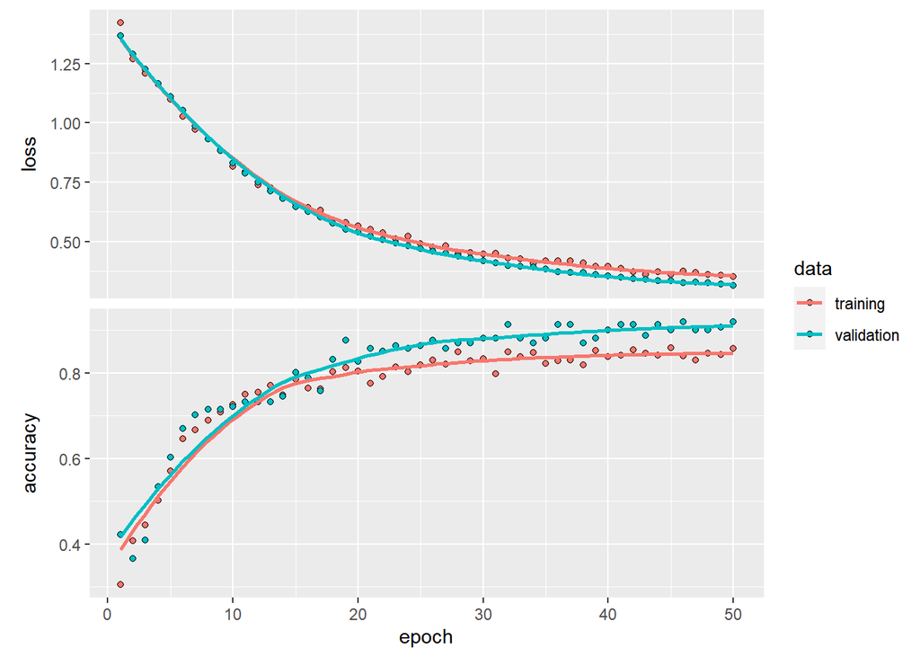

```r
plot(history_ann_1) # Mostramos los gáficos de perdida y precisión.
```

```r
set.seed(seed)
predicciones_ann_1 <- predict(modelo_ann_1, test_data_ann)
```

```
13/13 - 0s - 66ms/epoch - 5ms/step
```

```r
y_pred_ann_1 <- as.factor(max.col(predicciones_ann_1) - 1)
matriz_confusion_ann_1 <- confusionMatrix(y_pred_ann_1, as.factor(test_label_ann))
matriz_confusion_ann_1
```

```
Confusion Matrix and Statistics

          Reference
Prediction  0  1  2  3
         0 75  0 19  0
         1  0 80  2  0
         2 36  0 85  0
         3  0  0  0 99

Overall Statistics

               Accuracy : 0.8561
                 95% CI : (0.8176, 0.8891)
    No Information Rate : 0.2803
    P-Value [Acc > NIR] : < 2.2e-16

                  Kappa : 0.8074

 Mcnemar's Test P-Value : NA

Statistics by Class:

                     Class: 0 Class: 1 Class: 2 Class: 3
Sensitivity            0.6757   1.0000   0.8019     1.00
Specificity            0.9333   0.9937   0.8759     1.00
Pos Pred Value         0.7979   0.9756   0.7025     1.00
Neg Pred Value         0.8808   1.0000   0.9236     1.00
Prevalence             0.2803   0.2020   0.2677     0.25
Detection Rate         0.1894   0.2020   0.2146     0.25
Detection Prevalence   0.2374   0.2071   0.3056     0.25
Balanced Accuracy      0.8045   0.9968   0.8389     1.00
```

```r
# Modelo ann con dos capas ocultas.
modelo_ann_2 <- keras_model_sequential() %>%
  layer_dense(units = 25, activation = 'relu', input_shape = ncol(train_data_ann)) %>%
  layer_dropout(rate = 0.2) %>%
  layer_dense(units = 15, activation = 'relu') %>%
  layer_dropout(rate = 0.2) %>%
  layer_dense(units = 4, activation = 'softmax')
summary(modelo_ann_2)
```

```
Model: "sequential_1"
__________________________________________________________________________________________
 Layer (type)                           Output Shape                        Param #
==========================================================================================
 dense_4 (Dense)                        (None, 25)                          1150
 dropout_2 (Dropout)                    (None, 25)                          0
 dense_3 (Dense)                        (None, 15)                          390
 dropout_1 (Dropout)                    (None, 15)                          0
 dense_2 (Dense)                        (None, 4)                           64
==========================================================================================
Total params: 1604 (6.27 KB)
Trainable params: 1604 (6.27 KB)
Non-trainable params: 0 (0.00 Byte)
__________________________________________________________________________________________
```

```r
set.seed(seed)

# Compilamos el modelo_ann_2:
modelo_ann_2 %>% keras::compile(
  loss = 'sparse_categorical_crossentropy',
  optimizer = optimizer_adam(),
  metrics = c('accuracy')
)
# Entrenamos el modelo_ann_2 y almacenamos la información en la variable "history__ann_2":
history_ann_2 <- modelo_ann_2 %>% fit(
  x = train_data_ann,
  y = train_label_ann,
  epochs = 50,
  validation_split = 0.2,
  verbose = 2
)
```

```
21/21 - 1s - loss: 1.3463 - accuracy: 0.3064 - val_loss: 1.2976 - val_accuracy: 0.4224 - 685ms/epoch - 33ms/step
21/21 - 0s - loss: 1.2434 - accuracy: 0.4821 - val_loss: 1.2048 - val_accuracy: 0.5901 - 53ms/epoch - 3ms/step
21/21 - 0s - loss: 1.1474 - accuracy: 0.5505 - val_loss: 1.0915 - val_accuracy: 0.6087 - 55ms/epoch - 3ms/step
21/21 - 0s - loss: 1.0672 - accuracy: 0.5785 - val_loss: 0.9805 - val_accuracy: 0.6398 - 49ms/epoch - 2ms/step
21/21 - 0s - loss: 0.9645 - accuracy: 0.5972 - val_loss: 0.8772 - val_accuracy: 0.6398 - 52ms/epoch - 2ms/step
21/21 - 0s - loss: 0.8629 - accuracy: 0.6610 - val_loss: 0.7885 - val_accuracy: 0.6460 - 51ms/epoch - 2ms/step
21/21 - 0s - loss: 0.8165 - accuracy: 0.6858 - val_loss: 0.7269 - val_accuracy: 0.6832 - 52ms/epoch - 2ms/step
21/21 - 0s - loss: 0.7441 - accuracy: 0.6890 - val_loss: 0.6800 - val_accuracy: 0.6957 - 49ms/epoch - 2ms/step
21/21 - 0s - loss: 0.7180 - accuracy: 0.7092 - val_loss: 0.6394 - val_accuracy: 0.6957 - 51ms/epoch - 2ms/step
21/21 - 0s - loss: 0.6816 - accuracy: 0.7107 - val_loss: 0.6045 - val_accuracy: 0.7019 - 54ms/epoch - 3ms/step
21/21 - 0s - loss: 0.6607 - accuracy: 0.7247 - val_loss: 0.5699 - val_accuracy: 0.7516 - 51ms/epoch - 2ms/step
21/21 - 0s - loss: 0.6336 - accuracy: 0.7372 - val_loss: 0.5483 - val_accuracy: 0.7516 - 51ms/epoch - 2ms/step
21/21 - 0s - loss: 0.6007 - accuracy: 0.7683 - val_loss: 0.5254 - val_accuracy: 0.7640 - 51ms/epoch - 2ms/step
21/21 - 0s - loss: 0.5641 - accuracy: 0.7698 - val_loss: 0.5017 - val_accuracy: 0.8199 - 51ms/epoch - 2ms/step
21/21 - 0s - loss: 0.5416 - accuracy: 0.7792 - val_loss: 0.4803 - val_accuracy: 0.8261 - 53ms/epoch - 3ms/step
21/21 - 0s - loss: 0.5348 - accuracy: 0.7854 - val_loss: 0.4642 - val_accuracy: 0.8758 - 55ms/epoch - 3ms/step
21/21 - 0s - loss: 0.5240 - accuracy: 0.7807 - val_loss: 0.4464 - val_accuracy: 0.8820 - 54ms/epoch - 3ms/step
21/21 - 0s - loss: 0.5043 - accuracy: 0.7729 - val_loss: 0.4321 - val_accuracy: 0.8944 - 51ms/epoch - 2ms/step
21/21 - 0s - loss: 0.4890 - accuracy: 0.8056 - val_loss: 0.4241 - val_accuracy: 0.8820 - 50ms/epoch - 2ms/step
21/21 - 0s - loss: 0.4706 - accuracy: 0.8118 - val_loss: 0.4084 - val_accuracy: 0.9006 - 50ms/epoch - 2ms/step
21/21 - 0s - loss: 0.4681 - accuracy: 0.8103 - val_loss: 0.3834 - val_accuracy: 0.9130 - 53ms/epoch - 3ms/step
21/21 - 0s - loss: 0.4559 - accuracy: 0.8227 - val_loss: 0.3837 - val_accuracy: 0.8820 - 50ms/epoch - 2ms/step
21/21 - 0s - loss: 0.4341 - accuracy: 0.8118 - val_loss: 0.3535 - val_accuracy: 0.9193 - 50ms/epoch - 2ms/step
21/21 - 0s - loss: 0.4082 - accuracy: 0.8289 - val_loss: 0.3518 - val_accuracy: 0.9006 - 49ms/epoch - 2ms/step
21/21 - 0s - loss: 0.4231 - accuracy: 0.8243 - val_loss: 0.3419 - val_accuracy: 0.9068 - 48ms/epoch - 2ms/step
21/21 - 0s - loss: 0.4245 - accuracy: 0.8243 - val_loss: 0.3313 - val_accuracy: 0.9193 - 46ms/epoch - 2ms/step
21/21 - 0s - loss: 0.3921 - accuracy: 0.8538 - val_loss: 0.3202 - val_accuracy: 0.9193 - 50ms/epoch - 2ms/step
21/21 - 0s - loss: 0.3818 - accuracy: 0.8491 - val_loss: 0.3109 - val_accuracy: 0.9317 - 48ms/epoch - 2ms/step
21/21 - 0s - loss: 0.3638 - accuracy: 0.8694 - val_loss: 0.3092 - val_accuracy: 0.9130 - 49ms/epoch - 2ms/step
21/21 - 0s - loss: 0.3595 - accuracy: 0.8507 - val_loss: 0.2982 - val_accuracy: 0.9193 - 48ms/epoch - 2ms/step
21/21 - 0s - loss: 0.3617 - accuracy: 0.8383 - val_loss: 0.2957 - val_accuracy: 0.9130 - 50ms/epoch - 2ms/step
21/21 - 0s - loss: 0.3563 - accuracy: 0.8616 - val_loss: 0.2886 - val_accuracy: 0.9193 - 49ms/epoch - 2ms/step
21/21 - 0s - loss: 0.3494 - accuracy: 0.8538 - val_loss: 0.2778 - val_accuracy: 0.9379 - 47ms/epoch - 2ms/step
21/21 - 0s - loss: 0.3543 - accuracy: 0.8538 - val_loss: 0.2836 - val_accuracy: 0.9130 - 47ms/epoch - 2ms/step
21/21 - 0s - loss: 0.3349 - accuracy: 0.8709 - val_loss: 0.2701 - val_accuracy: 0.9317 - 47ms/epoch - 2ms/step
21/21 - 0s - loss: 0.3447 - accuracy: 0.8569 - val_loss: 0.2659 - val_accuracy: 0.9255 - 46ms/epoch - 2ms/step
21/21 - 0s - loss: 0.3290 - accuracy: 0.8725 - val_loss: 0.2601 - val_accuracy: 0.9255 - 50ms/epoch - 2ms/step
21/21 - 0s - loss: 0.3377 - accuracy: 0.8694 - val_loss: 0.2538 - val_accuracy: 0.9255 - 53ms/epoch - 3ms/step
21/21 - 0s - loss: 0.3175 - accuracy: 0.8709 - val_loss: 0.2494 - val_accuracy: 0.9193 - 61ms/epoch - 3ms/step
21/21 - 0s - loss: 0.3224 - accuracy: 0.8740 - val_loss: 0.2684 - val_accuracy: 0.8882 - 48ms/epoch - 2ms/step
21/21 - 0s - loss: 0.3267 - accuracy: 0.8616 - val_loss: 0.2387 - val_accuracy: 0.9379 - 58ms/epoch - 3ms/step
21/21 - 0s - loss: 0.3116 - accuracy: 0.8663 - val_loss: 0.2407 - val_accuracy: 0.9317 - 52ms/epoch - 2ms/step
21/21 - 0s - loss: 0.3058 - accuracy: 0.8818 - val_loss: 0.2315 - val_accuracy: 0.9317 - 50ms/epoch - 2ms/step
21/21 - 0s - loss: 0.2837 - accuracy: 0.8911 - val_loss: 0.2295 - val_accuracy: 0.9317 - 54ms/epoch - 3ms/step
21/21 - 0s - loss: 0.3039 - accuracy: 0.8834 - val_loss: 0.2267 - val_accuracy: 0.9317 - 48ms/epoch - 2ms/step
21/21 - 0s - loss: 0.3136 - accuracy: 0.8694 - val_loss: 0.2302 - val_accuracy: 0.9255 - 63ms/epoch - 3ms/step
21/21 - 0s - loss: 0.2898 - accuracy: 0.8849 - val_loss: 0.2261 - val_accuracy: 0.9317 - 73ms/epoch - 3ms/step
21/21 - 0s - loss: 0.2612 - accuracy: 0.8989 - val_loss: 0.2140 - val_accuracy: 0.9441 - 52ms/epoch - 2ms/step
21/21 - 0s - loss: 0.2866 - accuracy: 0.8880 - val_loss: 0.2246 - val_accuracy: 0.9379 - 50ms/epoch - 2ms/step
21/21 - 0s - loss: 0.2850 - accuracy: 0.8725 - val_loss: 0.2127 - val_accuracy: 0.9317 - 54ms/epoch - 3ms/step
```

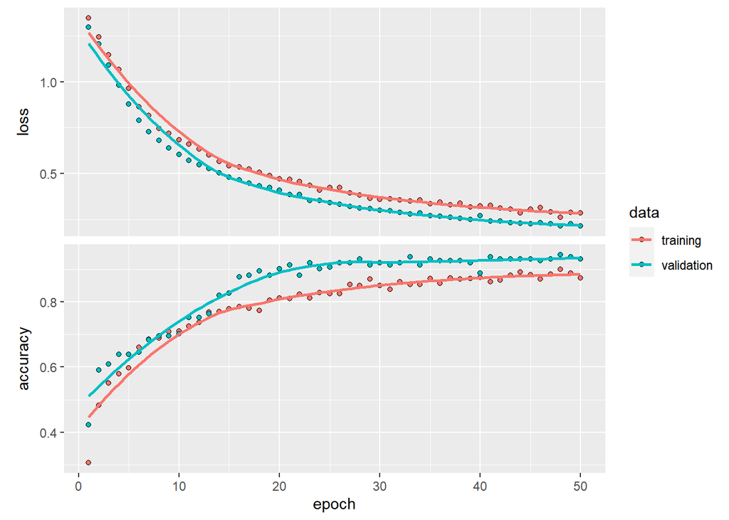

```r
plot(history_ann_2)
```

```r
set.seed(seed)
predicciones_ann_2 <- predict(modelo_ann_2, test_data_ann)
```

```
13/13 - 0s - 51ms/epoch - 4ms/step
```

```r
y_pred_ann_2 <- as.factor(max.col(predicciones_ann_2) - 1)
matriz_confusion_ann_2 <- confusionMatrix(y_pred_ann_2, as.factor(test_label_ann))
matriz_confusion_ann_2
```

```
Confusion Matrix and Statistics

          Reference
Prediction  0  1  2  3
         0 94  0 19  0
         1  0 80  1  0
         2 17  0 86  0
         3  0  0  0 99

Overall Statistics

               Accuracy : 0.9066
                 95% CI : (0.8735, 0.9334)
    No Information Rate : 0.2803
    P-Value [Acc > NIR] : < 2.2e-16

                  Kappa : 0.8748

 Mcnemar's Test P-Value : NA

Statistics by Class:

                     Class: 0 Class: 1 Class: 2 Class: 3
Sensitivity            0.8468   1.0000   0.8113     1.00
Specificity            0.9333   0.9968   0.9414     1.00
Pos Pred Value         0.8319   0.9877   0.8350     1.00
Neg Pred Value         0.9399   1.0000   0.9317     1.00
Prevalence             0.2803   0.2020   0.2677     0.25
Detection Rate         0.2374   0.2020   0.2172     0.25
Detection Prevalence   0.2854   0.2045   0.2601     0.25
Balanced Accuracy      0.8901   0.9984   0.8764     1.00
```

Comparación de Modelos (‘ANN’)

|  | Modelo | Accuracy | Kappa | Error_rate | Sensitivity_AFF | Sensitivity_ARR | Sensitivity_CHF | Sensitivity_NSR |
| --- | --- | --- | --- | --- | --- | --- | --- | --- |
| 2 | ANN Two layers | 0.907 | 0.875 | 0.093 | 0.847 | 1 | 0.811 | 1 |
| 1 | ANN One layer | 0.856 | 0.807 | 0.144 | 0.676 | 1 | 0.802 | 1 |

Los valores de sensibilidad para el modelo con mejor precisión son 84.7% para la clase AFF, 100% para la clase ARR, 81.1% para la clase CHF y 100% para la última clase NSR.

Si nuestros modelos son muy similares, seguiremos el principio de parsimonia y elegiremos el modelo mas sencillo.

## Support Vector Machine

Para implementar el algoritmo **upport Vector Machine (SVM)** con kernel lineal y RBF usamos la funcion `ksvm` del paquete *‘kernlab’* (Karatzoglou, Smola, and Hornik 2023). Para el kernel lineal usamos la opción **“vanilladot”** y **“rbfdot”** para RBF. Luego mostramos las matrices de confusión de cada modelo con la función `confusionMatrix()`del paquete *‘caret’*.

```r
set.seed(seed)

# Convertimos las clases a tipo factor para poder implementar el algoritmo SVM.
train_data$ECG_signal <- as.factor(train_data$ECG_signal)
test_data$ECG_signal <- as.factor(test_data$ECG_signal)

# Modelo SVM con kernel lineal.
svm_linear_model <- kernlab::ksvm(ECG_signal ~ ., data = train_data, kernel = "vanilladot")
svm_linear_model
```

```
Support Vector Machine object of class "ksvm"

SV type: C-svc  (classification)
 parameter : cost C = 1

Linear (vanilla) kernel function.

Number of Support Vectors : 110

Objective Function Value : -0.6662 -50.3855 -0.2015 -0.8317 -0.0483 -0.1472
Training error : 0.014925
```

```r
predictions_linear <- predict(svm_linear_model, newdata = test_data)

# Modelo SVM con kernel rbf>
svm_rbf_model <- kernlab::ksvm(ECG_signal ~ ., data = train_data, kernel = "rbfdot")
svm_rbf_model
```

```
Support Vector Machine object of class "ksvm"

SV type: C-svc  (classification)
 parameter : cost C = 1

Gaussian Radial Basis kernel function.
 Hyperparameter : sigma =  0.0259397406256988

Number of Support Vectors : 269

Objective Function Value : -20.1491 -113.2324 -8.1272 -19.8548 -5.2133 -6.7519
Training error : 0.021144
```

```r
predictions_rbf <- predict(svm_rbf_model, newdata = test_data)

#Matrices de confusión para los modelos.
linear_model <- caret::confusionMatrix(predictions_linear, test_data$ECG_signal)
rbf_model <- caret::confusionMatrix(predictions_rbf, test_data$ECG_signal)
# Mostramos los datos.
linear_model
```

```
Confusion Matrix and Statistics

          Reference
Prediction AFF ARR CHF NSR
       AFF  96   0   1   1
       ARR   0  80   0   0
       CHF  15   0 105   0
       NSR   0   0   0  98

Overall Statistics

               Accuracy : 0.9571
                 95% CI : (0.9322, 0.9748)
    No Information Rate : 0.2803
    P-Value [Acc > NIR] : < 2.2e-16

                  Kappa : 0.9425

 Mcnemar's Test P-Value : NA

Statistics by Class:

                     Class: AFF Class: ARR Class: CHF Class: NSR
Sensitivity              0.8649      1.000     0.9906     0.9899
Specificity              0.9930      1.000     0.9483     1.0000
Pos Pred Value           0.9796      1.000     0.8750     1.0000
Neg Pred Value           0.9497      1.000     0.9964     0.9966
Prevalence               0.2803      0.202     0.2677     0.2500
Detection Rate           0.2424      0.202     0.2652     0.2475
Detection Prevalence     0.2475      0.202     0.3030     0.2475
Balanced Accuracy        0.9289      1.000     0.9694     0.9949
```

```r
rbf_model
```

```
Confusion Matrix and Statistics

          Reference
Prediction AFF ARR CHF NSR
       AFF  96   0   4   0
       ARR   0  80   0   1
       CHF  15   0 102   0
       NSR   0   0   0  98

Overall Statistics

               Accuracy : 0.9495
                 95% CI : (0.9231, 0.9689)
    No Information Rate : 0.2803
    P-Value [Acc > NIR] : < 2.2e-16

                  Kappa : 0.9324

 Mcnemar's Test P-Value : NA

Statistics by Class:

                     Class: AFF Class: ARR Class: CHF Class: NSR
Sensitivity              0.8649     1.0000     0.9623     0.9899
Specificity              0.9860     0.9968     0.9483     1.0000
Pos Pred Value           0.9600     0.9877     0.8718     1.0000
Neg Pred Value           0.9493     1.0000     0.9857     0.9966
Prevalence               0.2803     0.2020     0.2677     0.2500
Detection Rate           0.2424     0.2020     0.2576     0.2475
Detection Prevalence     0.2525     0.2045     0.2955     0.2475
Balanced Accuracy        0.9254     0.9984     0.9553     0.9949
```

Comparación de Modelos (‘SVM’)

| Modelo | Accuracy | Kappa | Error_rate | Sensitivity_AFF | Sensitivity_ARR | Sensitivity_CHF | Sensitivity_NSR |
| --- | --- | --- | --- | --- | --- | --- | --- |
| SVM Lineal | 0.957 | 0.943 | 0.043 | 0.865 | 1 | 0.991 | 0.99 |
| SVM gaussiano | 0.949 | 0.932 | 0.051 | 0.865 | 1 | 0.962 | 0.99 |

Al comparar los modelos de la tabla anterior observamos que el modelo obtenido con SVM lineal tiene una mayor precisión , el valor kappa también es superior en el modelo lineal y el valor de error es superior en el modelo radial .

Los valores de sensibilidad para el modelo con mejor precisión son 86.5% para la clase AFF, 100% para la clase ARR, 99.1% para la clase CHF y 99% para la última clase NSR.

Si ambos modelos son muy similares, optaremos por el modelo más sencillo.

## Árbol de Clasificación

En el siguiente apartado, implementaremos el algoritmo de **Árbol de clasificación** con el paquete *`C50`* (Kuhn and Quinlan 2023) y la función `C5.0()`. En este caso, exploraremos la implementación de dos modelos: uno sin activar la opción de boosting y otro modelo activando el boosting usando un valor de *trials* igual a 10. También incluiremos las figuras que muestren de forma visual el árbol de clasificación. Por ultimo, se mostrará una tabla resumen de las matrices de confusión de cada modelo.

```r
set.seed(seed)
# Modelo sin boosting.
model_tree_1 <- C5.0(train_data[,-1], train_data$ECG_signal, trials = 1)
summary(model_tree_1)
```

```
Call:
C5.0.default(x = train_data[, -1], y = train_data$ECG_signal, trials = 1)


C5.0 [Release 2.07 GPL Edition]     Sun Jan 28 10:27:29 2024
-------------------------------

Class specified by attribute `outcome'

Read 804 cases (46 attributes) from undefined.data

Decision tree:

RTdis <= 0.1667871: NSR (201)
RTdis > 0.1667871:
:...NNTot <= 0.3677419: ARR (221/1)
    NNTot > 0.3677419:
    :...NNTot > 0.483871: AFF (136)
        NNTot <= 0.483871:
        :...NNTot <= 0.4451613:
            :...IBISD > 0.0210566: AFF (18)
            :   IBISD <= 0.0210566:
            :   :...SDSD > 0.007752874: CHF (3)
            :       SDSD <= 0.007752874:
            :       :...STdis <= 0.4298038: AFF (4)
            :           STdis > 0.4298038: CHF (3)
            NNTot > 0.4451613:
            :...RRmean > 0.1718247: AFF (6)
                RRmean <= 0.1718247:
                :...NN50 > 0.3783784:
                    :...SDRR <= 0.02383286: CHF (8)
                    :   SDRR > 0.02383286: AFF (18/1)
                    NN50 <= 0.3783784:
                    :...NNTot <= 0.4645161: CHF (143/2)
                        NNTot > 0.4645161:
                        :...PPmean <= 0.1315211: CHF (33/1)
                            PPmean > 0.1315211:
                            :...SToffdis <= 0.4203458: AFF (6/1)
                                SToffdis > 0.4203458: CHF (4)

```

[output cut: 18 more lines]

```
    Attribute usage:

    100.00% RTdis
     75.00% NNTot
     27.11% RRmean
     26.37% NN50
      5.35% PPmean
      3.48% IBISD
      3.23% SDRR
      1.24% SToffdis
      1.24% SDSD
      0.87% STdis


Time: 0.0 secs
```

[figure not shown]

```r
plot(model_tree_1)
```

```r
set.seed(seed)
pred_tree_1 <- predict(model_tree_1, test_data)
matriz_confusion_tree_1 <- confusionMatrix(pred_tree_1, test_data$ECG_signal)
matriz_confusion_tree_1
```

```
Confusion Matrix and Statistics

          Reference
Prediction AFF ARR CHF NSR
       AFF 103   1   7   1
       ARR   1  79   2   0
       CHF   7   0  97   0
       NSR   0   0   0  98

Overall Statistics

               Accuracy : 0.952
                 95% CI : (0.9261, 0.9709)
    No Information Rate : 0.2803
    P-Value [Acc > NIR] : < 2.2e-16

                  Kappa : 0.9357

 Mcnemar's Test P-Value : NA

Statistics by Class:

                     Class: AFF Class: ARR Class: CHF Class: NSR
Sensitivity              0.9279     0.9875     0.9151     0.9899
Specificity              0.9684     0.9905     0.9759     1.0000
Pos Pred Value           0.9196     0.9634     0.9327     1.0000
Neg Pred Value           0.9718     0.9968     0.9692     0.9966
Prevalence               0.2803     0.2020     0.2677     0.2500
Detection Rate           0.2601     0.1995     0.2449     0.2475
Detection Prevalence     0.2828     0.2071     0.2626     0.2475
Balanced Accuracy        0.9482     0.9890     0.9455     0.9949
```

```r
set.seed(seed)
# Modelo aplicando boosting (trials = 10).
model_tree_2 <- C5.0(train_data[,-1], train_data$ECG_signal, trials = 10)
summary(model_tree_2)
```

```
Call:
C5.0.default(x = train_data[, -1], y = train_data$ECG_signal, trials = 10)


C5.0 [Release 2.07 GPL Edition]     Sun Jan 28 10:27:30 2024
-------------------------------

Class specified by attribute `outcome'

Read 804 cases (46 attributes) from undefined.data

-----  Trial 0:  -----

Decision tree:

RTdis <= 0.1667871: NSR (201)
RTdis > 0.1667871:
:...NNTot <= 0.3677419: ARR (221/1)
    NNTot > 0.3677419:
    :...NNTot > 0.483871: AFF (136)
        NNTot <= 0.483871:
        :...NNTot <= 0.4451613:
            :...IBISD > 0.0210566: AFF (18)
            :   IBISD <= 0.0210566:
            :   :...SDSD > 0.007752874: CHF (3)
            :       SDSD <= 0.007752874:
            :       :...STdis <= 0.4298038: AFF (4)
            :           STdis > 0.4298038: CHF (3)
            NNTot > 0.4451613:
            :...RRmean > 0.1718247: AFF (6)
                RRmean <= 0.1718247:
                :...NN50 > 0.3783784:
                    :...SDRR <= 0.02383286: CHF (8)
                    :   SDRR > 0.02383286: AFF (18/1)
                    NN50 <= 0.3783784:
                    :...NNTot <= 0.4645161: CHF (143/2)
                        NNTot > 0.4645161:
                        :...PPmean <= 0.1315211: CHF (33/1)
                            PPmean > 0.1315211:
                            :...SToffdis <= 0.4203458: AFF (6/1)
```

[output cut: 301 more lines]

```
     30.60% IBISD
     30.47% STslope
     29.85% PQdis
     27.86% PQslope
     24.25% PPmean
     15.92% pNN50
     11.82% PonQdis
      6.97% RToffdis
      6.34% QRseg
      5.60% QTseg
      4.85% PonToffdis
      4.73% QTdis


Time: 0.2 secs
```

[figure not shown]

```r
plot(model_tree_2)
```

```r
set.seed(seed)
pred_tree_2 <- predict(model_tree_2, test_data)
matriz_confusion_tree_2 <- confusionMatrix(pred_tree_2, test_data$ECG_signal)
matriz_confusion_tree_2
```

```
Confusion Matrix and Statistics

          Reference
Prediction AFF ARR CHF NSR
       AFF 104   1   2   1
       ARR   1  79   2   0
       CHF   6   0 102   0
       NSR   0   0   0  98

Overall Statistics

               Accuracy : 0.9672
                 95% CI : (0.9445, 0.9824)
    No Information Rate : 0.2803
    P-Value [Acc > NIR] : < 2.2e-16

                  Kappa : 0.956

 Mcnemar's Test P-Value : NA

Statistics by Class:

                     Class: AFF Class: ARR Class: CHF Class: NSR
Sensitivity              0.9369     0.9875     0.9623     0.9899
Specificity              0.9860     0.9905     0.9793     1.0000
Pos Pred Value           0.9630     0.9634     0.9444     1.0000
Neg Pred Value           0.9757     0.9968     0.9861     0.9966
Prevalence               0.2803     0.2020     0.2677     0.2500
Detection Rate           0.2626     0.1995     0.2576     0.2475
Detection Prevalence     0.2727     0.2071     0.2727     0.2475
Balanced Accuracy        0.9615     0.9890     0.9708     0.9949
```

Comparación de Modelos (‘Árbol de clasificación’)

|  | Modelo | Accuracy | Kappa | Error_rate | Sensitivity_AFF | Sensitivity_ARR | Sensitivity_CHF | Sensitivity_NSR |
| --- | --- | --- | --- | --- | --- | --- | --- | --- |
| 2 | Tree with boosting | 0.967 | 0.956 | 0.033 | 0.937 | 0.988 | 0.962 | 0.99 |
| 1 | Tree without boosting | 0.952 | 0.936 | 0.048 | 0.928 | 0.988 | 0.915 | 0.99 |

Los valores de sensibilidad para el modelo con mejor precisión son 93.7% para la clase AFF, 98.8% para la clase ARR, 96.2% para la clase CHF y 99% para la última clase NSR.

Si las características de los modelos de árbol de clasificación son similares, optaremos por elegir la opción más sencilla.

## Random Forest

En este último apartado implementaremos el último algoritmo de la práctica evaluable. Se trata del algoritmo **Random Forest**. Para implementar los dos últimos modelos, usaremos la función `randomForest` del paquete *`randomForest`* (Liaw and Wiener 2002). Se presentará de forma gráfica la evolución del error de nuestras clases a medida que se construyen los árboles. Además, se presentará una tabla con las métricas de ambos modelos derivadas de las matrices de confusión.

```r
set.seed(seed)

modelo_rforest_1 <- randomForest(ECG_signal ~ ., data = train_data, ntree = 100)
modelo_rforest_1
```

```
Call:
 randomForest(formula = ECG_signal ~ ., data = train_data, ntree = 100)
               Type of random forest: classification
                     Number of trees: 100
No. of variables tried at each split: 6

        OOB estimate of  error rate: 1.62%
Confusion matrix:
    AFF ARR CHF NSR class.error
AFF 181   0   8   0  0.04232804
ARR   0 220   0   0  0.00000000
CHF   4   1 189   0  0.02577320
NSR   0   0   0 201  0.00000000
```

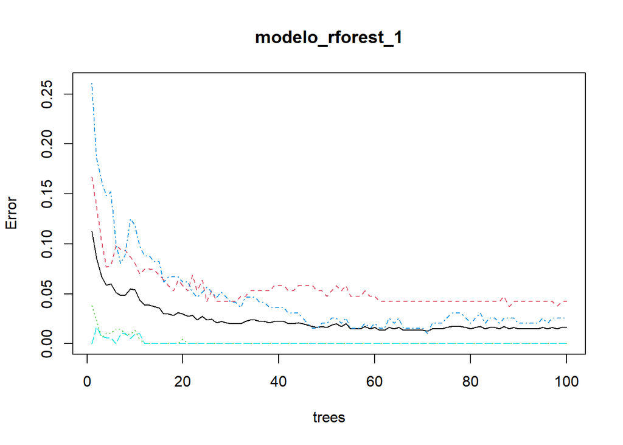

```r
plot(modelo_rforest_1)
```

```r
set.seed(seed)
pred_rforest_1 <- predict(modelo_rforest_1, newdata = test_data)
matriz_confusion_rforest_1 <- confusionMatrix(pred_rforest_1 , test_data$ECG_signal)
matriz_confusion_rforest_1
```

```
Confusion Matrix and Statistics

          Reference
Prediction AFF ARR CHF NSR
       AFF 106   0   1   0
       ARR   0  80   1   0
       CHF   5   0 104   0
       NSR   0   0   0  99

Overall Statistics

               Accuracy : 0.9823
                 95% CI : (0.9639, 0.9929)
    No Information Rate : 0.2803
    P-Value [Acc > NIR] : < 2.2e-16

                  Kappa : 0.9763

 Mcnemar's Test P-Value : NA

Statistics by Class:

                     Class: AFF Class: ARR Class: CHF Class: NSR
Sensitivity              0.9550     1.0000     0.9811       1.00
Specificity              0.9965     0.9968     0.9828       1.00
Pos Pred Value           0.9907     0.9877     0.9541       1.00
Neg Pred Value           0.9827     1.0000     0.9930       1.00
Prevalence               0.2803     0.2020     0.2677       0.25
Detection Rate           0.2677     0.2020     0.2626       0.25
Detection Prevalence     0.2702     0.2045     0.2753       0.25
Balanced Accuracy        0.9757     0.9984     0.9819       1.00
```

```r
set.seed(seed)

modelo_rforest_2 <- randomForest(ECG_signal ~ ., data = train_data, ntree = 200)
modelo_rforest_2
```

```
Call:
 randomForest(formula = ECG_signal ~ ., data = train_data, ntree = 200)
               Type of random forest: classification
                     Number of trees: 200
No. of variables tried at each split: 6

        OOB estimate of  error rate: 1.37%
Confusion matrix:
    AFF ARR CHF NSR class.error
AFF 181   0   8   0  0.04232804
ARR   0 220   0   0  0.00000000
CHF   2   1 191   0  0.01546392
NSR   0   0   0 201  0.00000000
```

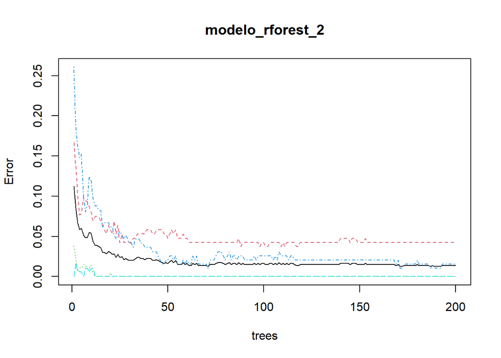

```r
plot(modelo_rforest_2)
```

```r
set.seed(seed)
pred_rforest_2 <- predict(modelo_rforest_2, newdata = test_data)
matriz_confusion_rforest_2 <- confusionMatrix(pred_rforest_2 , test_data$ECG_signal)
matriz_confusion_rforest_2
```

```
Confusion Matrix and Statistics

          Reference
Prediction AFF ARR CHF NSR
       AFF 105   0   1   0
       ARR   0  80   1   0
       CHF   6   0 104   0
       NSR   0   0   0  99

Overall Statistics

               Accuracy : 0.9798
                 95% CI : (0.9606, 0.9912)
    No Information Rate : 0.2803
    P-Value [Acc > NIR] : < 2.2e-16

                  Kappa : 0.9729

 Mcnemar's Test P-Value : NA

Statistics by Class:

                     Class: AFF Class: ARR Class: CHF Class: NSR
Sensitivity              0.9459     1.0000     0.9811       1.00
Specificity              0.9965     0.9968     0.9793       1.00
Pos Pred Value           0.9906     0.9877     0.9455       1.00
Neg Pred Value           0.9793     1.0000     0.9930       1.00
Prevalence               0.2803     0.2020     0.2677       0.25
Detection Rate           0.2652     0.2020     0.2626       0.25
Detection Prevalence     0.2677     0.2045     0.2778       0.25
Balanced Accuracy        0.9712     0.9984     0.9802       1.00
```

Comparación de Modelos (‘Ramdon Forest’)

| Modelo | Accuracy | Kappa | Error_rate | Sensitivity_AFF | Sensitivity_ARR | Sensitivity_CHF | Sensitivity_NSR |
| --- | --- | --- | --- | --- | --- | --- | --- |
| rForest n=100 | 0.982 | 0.976 | 0.018 | 0.955 | 1 | 0.981 | 1 |
| rForest n=200 | 0.980 | 0.973 | 0.020 | 0.946 | 1 | 0.981 | 1 |

Los valores de sensibilidad para el modelo con mejor precisión son 95.5% para la clase AFF, 100% para la clase ARR, 98.1% para la clase CHF y 100% para la última clase NSR.

Como en los modelos anteriores, si obtenemos métricas muy similares, volveremos a elegir el más sencillo.

# Discusión y Conclusión

En la siguiente tabla se presentan todos los modelos implementados en esta actividad, tenemos 15 modelos. Se incluyen las métricas de precisión (Accuracy), el valor Kappa, el ratio de error (Error_rate) y la sensibilidad de cada clase de estudio. Cada modelo se ha ordenado por su valor de precisión de mayor a menor.

Modelos

|  | Modelo | Accuracy | Kappa | Error_rate | Sensitivity_AFF | Sensitivity_ARR | Sensitivity_CHF | Sensitivity_NSR |
| --- | --- | --- | --- | --- | --- | --- | --- | --- |
| 15 | rForest n=100 | 0.982 | 0.976 | 0.018 | 0.955 | 1.000 | 0.981 | 1.00 |
| 25 | rForest n=200 | 0.980 | 0.973 | 0.020 | 0.946 | 1.000 | 0.981 | 1.00 |
| 1 | kNN k = 1 | 0.972 | 0.963 | 0.028 | 0.919 | 1.000 | 0.981 | 1.00 |
| 24 | Tree with boosting | 0.967 | 0.956 | 0.033 | 0.937 | 0.988 | 0.962 | 0.99 |
| 13 | SVM Lineal | 0.957 | 0.943 | 0.043 | 0.865 | 1.000 | 0.991 | 0.99 |
| 2 | kNN k = 3 | 0.955 | 0.939 | 0.045 | 0.865 | 1.000 | 0.972 | 1.00 |
| 14 | Tree without boosting | 0.952 | 0.936 | 0.048 | 0.928 | 0.988 | 0.915 | 0.99 |
| 23 | SVM gaussiano | 0.949 | 0.932 | 0.051 | 0.865 | 1.000 | 0.962 | 0.99 |
| 4 | kNN k = 7 | 0.942 | 0.922 | 0.058 | 0.829 | 1.000 | 0.962 | 1.00 |
| 3 | kNN k = 5 | 0.939 | 0.919 | 0.061 | 0.820 | 1.000 | 0.962 | 1.00 |
| 5 | kNN k = 11 | 0.927 | 0.902 | 0.073 | 0.829 | 1.000 | 0.906 | 1.00 |
| 11 | NB Laplace = 0 | 0.907 | 0.875 | 0.093 | 0.892 | 0.900 | 0.858 | 0.98 |
| 22 | ANN Two layers | 0.907 | 0.875 | 0.093 | 0.847 | 1.000 | 0.811 | 1.00 |
| 21 | NB Laplace =1 | 0.904 | 0.871 | 0.096 | 0.892 | 0.900 | 0.849 | 0.98 |
| 12 | ANN One layer | 0.856 | 0.807 | 0.144 | 0.676 | 1.000 | 0.802 | 1.00 |

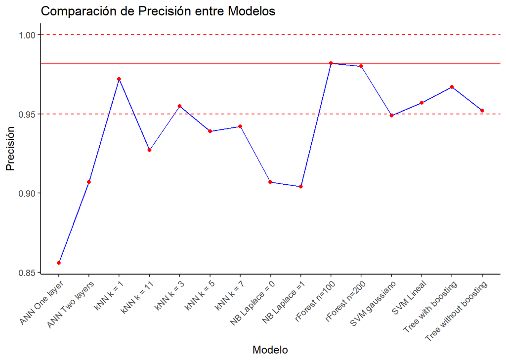

Para la clasificación de dolencias cardiacas hemos explorado distintos tipos de algoritmos. En la tabla anterior, podemos comparar las métricas de cada uno. Los mejores tres modelos se corresponden, de más preciso a menos, con rForest n=100, rForest n=200 y kNN k = 1. La precisión de los modelos varía desde 98.2% hasta 85.6%, lo que nos da una diferencia de un 12.6% entre el primero y el último. Sin embargo, entre el primer modelo y el segundo tenemos una diferencia del 0.2% y una diferencia con el tercero del 1%.

El modelo rForest n=100 tiene las mejores métricas en cuanto a precisión (98.2%), valor Kappa (97.6%), y ratio de error 1.8%. Los valores de sensibilidad para el modelo rForest n=100 con la mejor precisión (98.2%) son 95.5% para la clase AFF, 100% para la clase ARR, 98.1% para la clase CHF, y 100% para la última clase NSR.

A la hora de elegir un modelo, tenemos que tener en cuenta las métricas. Aun así, si nuestros modelos muestran valores muy similares, podemos establecer un valor de corte (cutoff). En nuestro caso, vamos a seleccionar los modelos que tengan una precisión del 95% o más:

Modelos Seleccionados

| x |
| --- |
| rForest n=100 |
| rForest n=200 |
| kNN k = 1 |
| Tree with boosting |
| SVM Lineal |
| kNN k = 3 |
| Tree without boosting |

De los modelos seleccionados, los dos primeros destacan por sus métricas. Como resultado final de esta práctica evaluable, elegimos estos modelos, rForest n=100 y rForest n=200, como los mejores para clasificar las dolencias cardiacas. Si los modelos coinciden en que son del mismo tipo de algoritmo, nos quedaremos únicamente con el más sencillo. De forma adicional, podríamos incluir el tercer tipo de modelo (kNN k = 1).

# Referencias

Allaire, JJ, and François Chollet. 2023. *Keras: R Interface to ’Keras’*. https://CRAN.R-project.org/package=keras.

Karatzoglou, Alexandros, Alex Smola, and Kurt Hornik. 2023. *Kernlab: Kernel-Based Machine Learning Lab*. https://CRAN.R-project.org/package=kernlab.

Kuhn, Max, and Ross Quinlan. 2023. *C50: C5.0 Decision Trees and Rule-Based Models*. https://CRAN.R-project.org/package=C50.

Kuhn, and Max. 2008. “Building Predictive Models in r Using the Caret Package.” *Journal of Statistical Software* 28 (5): 1–26. https://doi.org/10.18637/jss.v028.i05.

Lantz, Brett. 2019. *Machine Learning with r: Expert Techniques for Predictive Modeling*. Packt publishing ltd.

Liaw, Andy, and Matthew Wiener. 2002. “Classification and Regression by randomForest.” *R News* 2 (3): 18–22. https://CRAN.R-project.org/doc/Rnews/.

Meyer, David, Evgenia Dimitriadou, Kurt Hornik, Andreas Weingessel, and Friedrich Leisch. 2023. *E1071: Misc Functions of the Department of Statistics, Probability Theory Group (Formerly: E1071), TU Wien*. https://CRAN.R-project.org/package=e1071.

Venables, W. N., and B. D. Ripley. 2002. *Modern Applied Statistics with s*. Fourth. New York: Springer. https://www.stats.ox.ac.uk/pub/MASS4/.